# Run some basic smoothing on a timeseries

## Climate data simulation

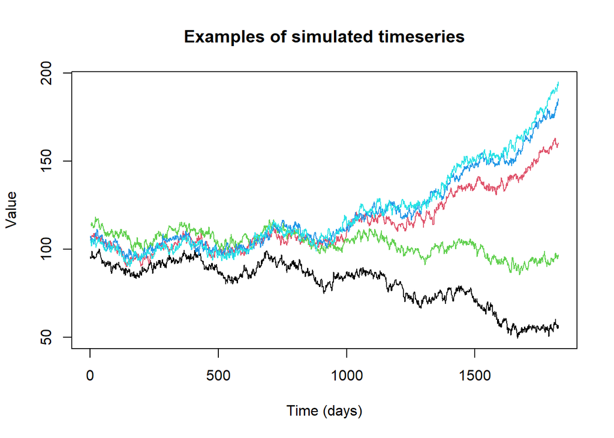

```r
#' Generate some toy climate timeseries
#'
#' @param arg_vals_days Vector (numeric). The timepoints for evaluation.
#' @param num_reps Numeric. Number of different timeseries.
#' @param mean_of_noise Numeric. Mean of noise (within ARIMA model).
#' @param spread_trends Numeric. Spread of the trends about 0.
#' @param spread_consts Numeric. Spread of the const values about 40.
generate_toy_climate_data <- function(
  arg_vals_days = 1:(2*365),
  num_reps = 2,
  mean_of_noise = 0.02,
  spread_trends = 5,
  const_avg = 100,
  spread_consts = 10,
  seed_in = 123
){
  set.seed(seed_in)  # for reproducibility
  trends = runif(num_reps, min = -spread_trends, max = spread_trends)
  consts = runif(num_reps, min = const_avg - spread_consts, max = const_avg + spread_consts)

  eg_df <- data.frame(matrix(nrow = length(arg_vals_days),
                             ncol = num_reps))
  colnames(eg_df) <- 1:num_reps

  for (j in 1:num_reps) {
    eg_fluc_data <- sapply(
      arg_vals_days,
      function(i) {
        consts[j] + trends[j]*(i/365)**3 + 5*cos(i*2*pi/365) + 0.3 * sin(i*pi/3)
      }
    ) + arima.sim(
      length(arg_vals_days),
      mean = mean_of_noise,
      model = list(order = c(1,0,0), ar = 0.9)
    )
    eg_df[, j] <- eg_fluc_data
  }
  return(eg_df)
}

arg_vals_days <- 1:(5*365)
example_data <- generate_toy_climate_data(
  arg_vals_days = arg_vals_days,
  num_reps = 5,
  spread_trends = 0.8,
  spread_consts = 10
)

matplot(
  example_data,
  type = 'l',
  col = 1:5,
  lty = 1,
  main = "Examples of simulated timeseries",
  xlab = "Time (days)",
  ylab = "Value"
)
```

Next, provide the user options to smooth the data. This consists of different basis function types and options for the amount of smoothing of the data.

```r
#' Fit a spline to a collection of timeseries, with a possible roughness penalty
#'
#' @param data_to_smooth A data frame. Rows correspond to different time points
#' and columns correspond to different variables.
#' @param timepoints A vector (numeric). Corresponds to the measurement
#' timepoints of each variable.
#' @param nbasis_in Integer. The number of basis functions to use.
#' @param lambda_in Float. Defaults to 0. The value of the smoothing parameter,
#' lambda.
#' @param basis_type String. Defaults to "fourier". Can be either "fourier" or
#' "bspline" to select different families of basis functions.
#' @param norder_in Integer. Defaults to 4. Only relevant if basis_type =
#' TRUE. Controls the order of the bspline functions.
#'
#' @return An fdSmooth object.
fits_from_params <- function(data_to_smooth,
                             timepoints,
                             nbasis_in,
                             lambda_in = 0,
                             basis_type = "fourier",
                             norder_in = 4) {
  range_of_timeseries <- c(min(timepoints), max(timepoints))

  penalty_basis <- switch(
    basis_type,
    fourier = fda::create.fourier.basis(
      rangeval = range_of_timeseries,
      nbasis = nbasis_in,

    ),
    bspline = fda::create.bspline.basis(
      rangeval = range_of_timeseries,
      nbasis = nbasis_in,
      norder = norder_in
    )
  )

  if (is.null(penalty_basis)) {
    stop('basis_type not recognised - must be "fourier" or "bspline"')
  }


  # Define a linear differential operator
  second_deriv_operator = fda::int2Lfd(2)

  fd_params = fda::fdPar(penalty_basis, second_deriv_operator, lambda_in)
  fd_outputs = fda::smooth.basis(
    timepoints,
    data_to_smooth,
    fd_params
  )

  return(fd_outputs)

}
```

Here are some specific examples of ‘smoothed’ output data. The user would be expected to select an appropriate smoothing by eye. (In general, there is no algorithmic approach to smooth a function perfectly and this is extremely variable depending on the dataset!)

```r
basic_output_fits <- fits_from_params(
  as.matrix(example_data),
  arg_vals_days,
  20,
  lambda_in = 50,
  basis_type = "bspline"
)

png("../results/good_timeseries_fits.png", width = 600, height = 500, pointsize = 16)
matplot(example_data, type = 'l', col = 1:5, lty = 1,
        main = "Examples of fits to timeseries",
        xlab = "Time (days)",
        ylab = "Value")
lines(basic_output_fits,
      col = 1:5,
      lty = 1)
dev.off()
```

Be aware - this can go wrong easily!

```r
basic_output_fits_bad <- fits_from_params(
  as.matrix(example_data),
  arg_vals_days,
  8,
  lambda_in = 500,
  basis_type = "bspline"
)

png("../results/bad_timeseries_fits.png", width = 600, height = 500, pointsize = 16)
matplot(example_data, type = 'l', col = 1:5, lty = 1,
        main = "Poor fits to timeseries",
        xlab = "Time (days)",
        ylab = "Value")
lines(basic_output_fits_bad,
      col = 1:5,
      lty = 1)
dev.off()
```

You can also smooth this data by taking the rolling average, as a pre-processing step before smoothing:

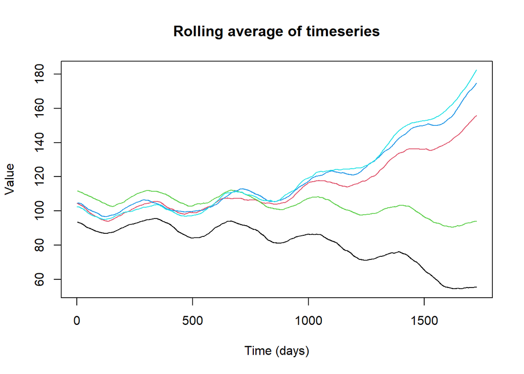

```r
# apply rollmean to each column, which contains an independent replicate
rolling_data <- apply(example_data, 2, function(col_in) {
  zoo::rollmean(col_in, k = 100)
})

matplot(rolling_data, type = 'l', col = 1:5, lty = 1,
        main = "Rolling average of timeseries",
        xlab = "Time (days)",
        ylab = "Value")
```

## Simulating economic data

For now, we can simulate some economic data by taking subsets of the climate data at specific timepoints.

```r
#' Takes an fd object (from FDA package), which  is assumed to be a densely timeseries, and produces a noisy and sparse subsample.
#'
#' @param climate_timeseries_fd fd object. The smoothed timeseries to manipulate into producing a sampled timeseries.
#' @param time_vec Numeric vector. Corresponds to the timepoints of climate_timeseries_fd to predict. NOTE: that the dataset will be manipulated and then sparsely sampled to match this.
#' @param x_stretch Numeric. The amount the 'stretch' the timeseries in the x (time) direction. For example, asking for timepoints 0, 2, 4 and asking for an x-stretch of 1/2 would actually sample timepoints 0, 1, 2.
#' @param y_stretch Numeric. The amount the 'stretch' the timeseries in the y (output) direction.
#' @param noise_level Numeric. The standard deviation of ARIMA model noise added in addition to the sampling.
reduce_climate_to_sparse <- function(climate_timeseries_fd,
                                     time_vec,
                                     which_rep = 1,
                                     x_stretch = 1,
                                     y_stretch = 1,
                                     noise_level = 1e-2) {

  # do x-shift
  min_time <- min(time_vec)
  max_time <- max(time_vec)
  freq_timeseries <- seq(min_time, max_time, length.out = 1000)
  new_eval_points <- (freq_timeseries - min_time) * x_stretch + min_time
  output_data <- fda::eval.fd(new_eval_points, climate_timeseries_fd)[, which_rep]

  # do y-shift
  output_data <- (output_data - min(output_data)) * y_stretch + min(output_data)

  # add noise
  output_data <- output_data + rnorm(length(output_data), sd = noise_level)

  # return evenly spaced timepoints
  sparse_sampling_pts <- seq(
    from = 1,
    to = length(output_data),
    length.out = length(time_vec)
  )

  return(output_data[sparse_sampling_pts])
}
```

## Example of searching the dataset

In order to compare the densely-sample timeseries with the sparse one, we first need to subsample our approximation of the timeseries.

[Dynamic Time Warping](https://en.wikipedia.org/wiki/Dynamic_time_warping) provides a method to compares two timeseries, which allows for realistic “stretching” of one timeseries against another. Additionally, as a dynamic programming algorithm, it is possible to search for a subset of a fit within the data.

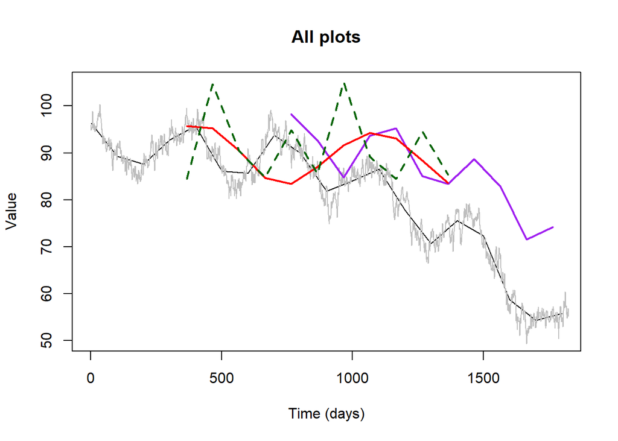

```r
sparse_climate_tps <- seq(from = 1, to = 5*365, by = 100)
full_evaluated_seq <- fda::eval.fd(sparse_climate_tps, basic_output_fits$fd)[,1]

sparse_tps <- seq(from = 366, to = 4*365, by = 100)
eg_econ_data_full <- reduce_climate_to_sparse(
  basic_output_fits[1]$fd,
  sparse_tps,
  x_stretch = 1,
  y_stretch = 1.1,
  noise_level = 0.1
)

eg_econ_data_short <- reduce_climate_to_sparse(
  basic_output_fits[1]$fd,
  sparse_tps,
  x_stretch = 1/2,
  noise_level = 1e-2
)

set.seed(123)
spread_of_negative_control <- sd(eg_econ_data_short) / 10
eg_uncorrelated_timeseries <- rep(c(-5, 15, 0, -5, 5), length.out = length(sparse_tps)) +
  rnorm(n = length(sparse_tps),
  mean = mean(eg_econ_data_short),
  sd = spread_of_negative_control)


plot(sparse_climate_tps, full_evaluated_seq, type = "l", ylim = c(50, 105),
     xlab = "Time (days)", ylab = "Value", main = "All plots")
lines(arg_vals_days, example_data[,1], col = "grey")
lines(sparse_tps + 400, eg_econ_data_full, type = "l", col = "purple", lwd = 2)
lines(sparse_tps, eg_econ_data_short, type = "l", col = "red", lwd = 2)
lines(sparse_tps, eg_uncorrelated_timeseries, type = "l", col = "darkgreen", lty = "dashed", lwd = 2)
```

```r
eg_econ_full_dtw <- dtw::dtw(
  eg_econ_data_full,
  full_evaluated_seq,
  open.end = TRUE,
  open.begin = TRUE,
  step.pattern = dtw::asymmetricP05
)
print(paste0("Distance from black to purple: ", eg_econ_full_dtw$normalizedDistance))
```

```
## [1] "Distance from black to purple: 2.06114927257456"
```

```r
eg_econ_short_dtw <- dtw::dtw(
  eg_econ_data_short,
  full_evaluated_seq,
  open.end = TRUE,
  open.begin = TRUE,
  step.pattern = dtw::asymmetric
)
print(paste0("Distance from black to red: ", eg_econ_short_dtw$normalizedDistance))
```

```
## [1] "Distance from black to red: 1.35556365707431"
```

```r
eg_uncor_dtw <- dtw::dtw(
  eg_uncorrelated_timeseries,
  full_evaluated_seq,
  open.end = TRUE,
  open.begin = TRUE,
  step.pattern = dtw::asymmetric
)
print(paste0("Distance from black to green: ", eg_uncor_dtw$normalizedDistance))
```

```
## [1] "Distance from black to green: 4.2501526297617"
```

```r
png("../results/shifted.png", pointsize = 16, width = 700, height = 500)
plot(sparse_climate_tps, full_evaluated_seq, type = "l", ylim = c(50, 105),
     xlab = "Time (days)", ylab = "Value", main = "Shifted timeseries")
lines(arg_vals_days, example_data[,1], col = "grey")
lines(sparse_tps + 400, eg_econ_data_full, type = "l", col = "purple", lwd = 2)
text(230, 54, paste0("DTW distance = ", sprintf("%.2f",  eg_econ_full_dtw$normalizedDistance)))
dev.off()
```

```r
png("../results/scaled.png", pointsize = 16, width = 700, height = 500)
plot(sparse_climate_tps, full_evaluated_seq, type = "l", ylim = c(50, 105),
     xlab = "Time (days)", ylab = "Value", main = "Misaligned peaks")
lines(arg_vals_days, example_data[,1], col = "grey")
lines(sparse_tps, eg_econ_data_short, type = "l", col = "red", lwd = 2)
text(230, 54, paste0("DTW distance = ", sprintf("%.2f",  eg_econ_short_dtw$normalizedDistance)))
dev.off()
```

```r
png("../results/uncorrelated.png", pointsize = 16, width = 700, height = 500)
plot(sparse_climate_tps, full_evaluated_seq, type = "l", ylim = c(50, 105),
     xlab = "Time (days)", ylab = "Value", main = "No correlation")
lines(arg_vals_days, example_data[,1], col = "grey")
lines(sparse_tps, eg_uncorrelated_timeseries, type = "l", col = "darkgreen", lty = "dashed", lwd = 2)
text(230, 54, paste0("DTW distance = ", sprintf("%.2f",  eg_uncor_dtw$normalizedDistance)))
dev.off()
```